# Profiles for genes of interest

Sandra

2023-10-19

## Normalisation of samples

### Normalisation by the total number of raw counts (equivalent of mapped library size)

```r
gene_types <- read_tsv("SC18_data/Genes_interest.txt")

SC18_all_WT <- read_tsv("SC18_data/SC18_Raw_HTSeq_WT.txt") %>%
  column_to_rownames(var="gene")


CPMnorm_SC18_all_WT <- cpmNormalization(SC18_all_WT)

CPM_SC18_all_WT <- as.data.frame.matrix(CPMnorm_SC18_all_WT)
```

### Z-score normalisation on top of the library size normalisation

```r
CPM_SC18_all_WT_Zscore <- mutate_all(CPM_SC18_all_WT, funs("Zscore" = (.-rowMeans(CPM_SC18_all_WT[,1:24], na.rm=TRUE))/rowSds(as.matrix(CPM_SC18_all_WT[,1:24])))) %>%
 dplyr::select( contains("Zscore")) %>%
  rename_with(~ gsub("_Zscore", "", .x, fixed = TRUE)) %>%
  rownames_to_column(var="gene")
```

## Measurement and plot of CV for genes involved in nitrate nutrition

### HVG plot with genes involved in nitrate nutrition

Removing lowly expressed genes and small genes (<150bp)

```r
CPM_SC18_all_WT_expr <-  filter(CPM_SC18_all_WT, rowMeans(CPM_SC18_all_WT[,1:24])>=5&
                            rowSums(CPM_SC18_all_WT[1:22]<0.0001)<5)


Gene_size <- read_tsv("SC18_data/TAIR10_Gene_sizes.txt") %>%
  dplyr::select(gene_name,length)

Genes_more150bp <-filter(Gene_size,length>150)

CPM_SC18_all_WT_expr <- rownames_to_column(CPM_SC18_all_WT_expr, var="gene") %>%
  inner_join( Genes_more150bp, by=c("gene"="gene_name")) %>%
  dplyr::select(-length) %>%
  column_to_rownames(var="gene") %>%
  as.data.frame()
```

HVG plot with genes of interest in different colors

```r
CPM_SC18_all_WT_expr_Brennecke <- BrenneckeGetVariableGenesMod(CPM_SC18_all_WT_expr, minBiolDisp = 0.1, fdr=0.01)
```

[figure not shown]

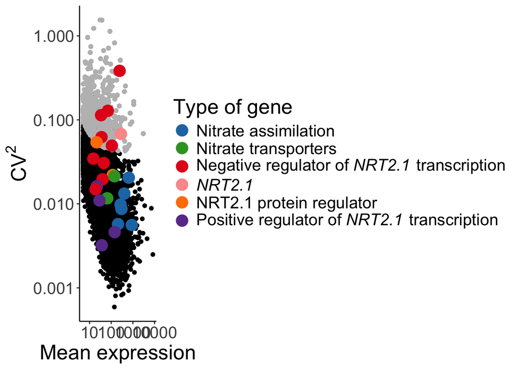

```r
CPM_SC18_all_WT_expr_a0 <-CPM_SC18_all_WT_expr_Brennecke$A0
CPM_SC18_all_WT_expr_a1 <- CPM_SC18_all_WT_expr_Brennecke$A1
CPM_SC18_all_WT_expr_Brennecke_data <- CPM_SC18_all_WT_expr_Brennecke$data
CPM_SC18_all_WT_expr_HVG <- filter(CPM_SC18_all_WT_expr_Brennecke_data, q.value<0.01)

CPM_SC18_all_WT_expr_Brennecke_genes_interest <- inner_join(CPM_SC18_all_WT_expr_Brennecke_data, gene_types, by=c("Gene"="gene"))

my_colors <- RColorBrewer::brewer.pal(12, "Paired")[c(2,4,6,5,8,10)]


ggplot(CPM_SC18_all_WT_expr_Brennecke_data, aes(x=Mean, y=CV2)) +
  geom_point() +
  scale_x_log10() + scale_y_log10() +
  xlab("Mean expression") +
  ylab(bquote(CV^2)) +
  geom_point(data=CPM_SC18_all_WT_expr_HVG,col="grey") +
 geom_point(data=CPM_SC18_all_WT_expr_Brennecke_genes_interest, aes(col=type),  size=5) +
  scale_color_manual(values = my_colors, name="Type of gene",
                     labels=expression("Nitrate assimilation",
                     "Nitrate transporters",
                     paste("Negative regulator of ", italic("NRT2.1"), " transcription"),
                     italic("NRT2.1"),
                     "NRT2.1 protein regulator",
                     paste("Positive regulator of ", italic("NRT2.1"), " transcription"))) +
  theme_classic() +
  theme(text = element_text(size = 20))
```

```r
ggsave("Variability_graph_genes_nitrate_nutrition.jpg", width=11, height = 4)
```

## Correlation between the expression in seedlings of NRT2.1 and different genes involved in nitrate nutrition

Tables of correlation between each gene and NRT2.1

```r
options(scipen=999)

CPM_SC18_all_WT_Zscore_1ColperGene <- inner_join(CPM_SC18_all_WT_Zscore, gene_types, by="gene") %>%
  pivot_longer( cols = c(A1:A9), names_to = "seedling", values_to = "Zscore_normalised_expression") %>%
  dplyr::select(-type, - gene) %>%
  pivot_wider(names_from = name, values_from = Zscore_normalised_expression) %>%
  column_to_rownames(var="seedling")

Rcor_NRT2.1_genes <- sapply(CPM_SC18_all_WT_Zscore_1ColperGene[-1], function(x) corr.test(x, CPM_SC18_all_WT_Zscore_1ColperGene$NRT2.1, method="spearman")$r) %>%
  as.data.frame()
Pcor_NRT2.1_genes <- sapply(CPM_SC18_all_WT_Zscore_1ColperGene[-1], function(x) corr.test(x, CPM_SC18_all_WT_Zscore_1ColperGene$NRT2.1, method="spearman")$p) %>%
  as.data.frame()
```

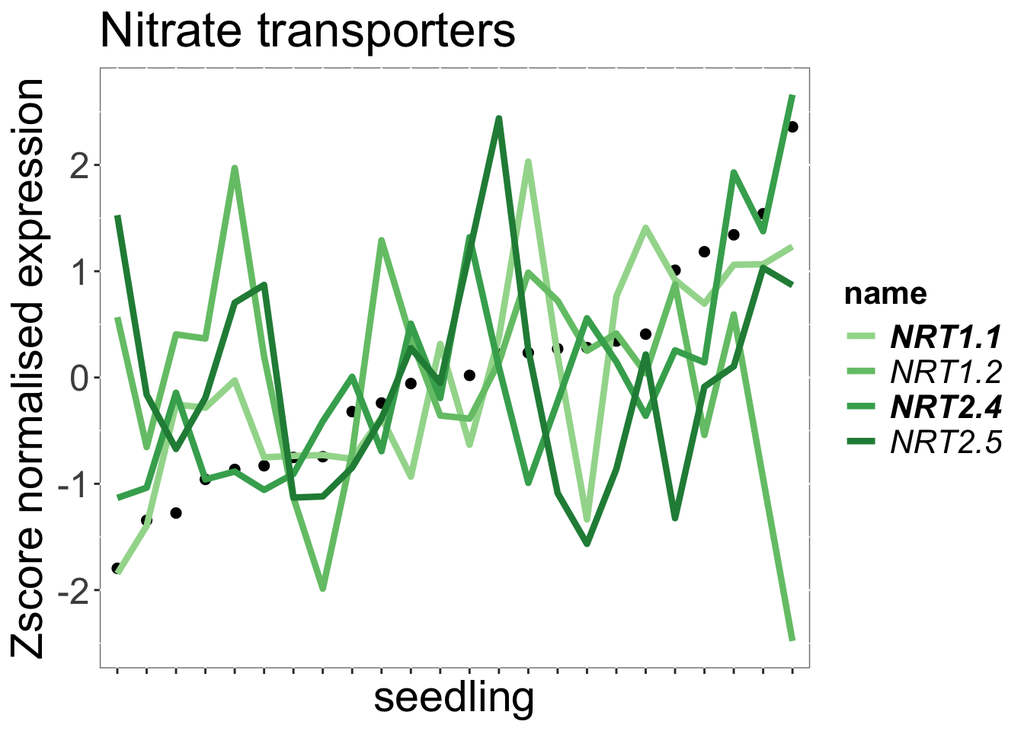

```r
CPM_SC18_all_WT_Zscore_long <- inner_join(CPM_SC18_all_WT_Zscore, gene_types, by="gene") %>%
  pivot_longer( cols = c(A1:A9), names_to = "seedling", values_to = "Zscore_normalised_expression")


NRT2.1_CPM_SC18_all_WT_Zscore_long <- filter(CPM_SC18_all_WT_Zscore_long, gene=="AT1G08090") %>%
  mutate(seedling=fct_reorder(seedling, Zscore_normalised_expression))

CPM_SC18_all_WT_Zscore_long_lessNRT2.1 <- filter(CPM_SC18_all_WT_Zscore_long, gene!="AT1G08090")

# Graph for N transporters

CPM_SC18_all_WT_Zscore_long_lessNRT2.1_N_transport <- filter(CPM_SC18_all_WT_Zscore_long_lessNRT2.1,
                                                                 type=="N_transport")



my_colors <- RColorBrewer::brewer.pal(8, "Greens")[4:7]

ggplot(NRT2.1_CPM_SC18_all_WT_Zscore_long, aes(x=seedling, y=Zscore_normalised_expression)) +
  geom_point(size=2) +
  geom_line(data=CPM_SC18_all_WT_Zscore_long_lessNRT2.1_N_transport, aes(x=seedling, y=Zscore_normalised_expression, group=name, color=name), size=1.5) +
  ylab("Zscore normalised expression") +
  ggtitle("Nitrate transporters") +
  scale_color_manual(values=my_colors, labels=c(expression(bolditalic("NRT1.1")), "NRT1.2",
                                                expression(bolditalic("NRT2.4")), "NRT2.5")) +
  theme(legend.text=element_text(size=16,face = "italic" ),legend.title = element_text(size=16, face="bold"),
        axis.text=element_text(size=18), axis.title=element_text(size=21.5),
        plot.title = element_text(size=24),
        panel.background = element_rect(fill = "white", colour = "grey50"),axis.text.x=element_blank(), legend.key = element_rect(fill = NA, color = NA))
```

```r
ggsave("Correlation_NRT2.1_Ntransporters_seedlings.jpg", width=5, height=4)
```

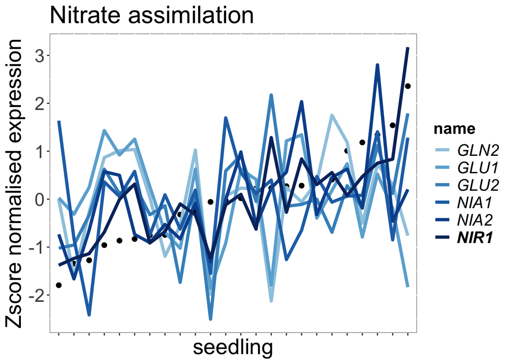

```r
# Graph for genes involved in N assimilation

my_colors_greens <- RColorBrewer::brewer.pal(9, "Blues")[4:9]


CPM_SC18_all_WT_Zscore_long_lessNRT2.1_Nassimilation <- filter(CPM_SC18_all_WT_Zscore_long_lessNRT2.1,
                                                                 type=="N_assimilation")

ggplot(NRT2.1_CPM_SC18_all_WT_Zscore_long, aes(x=seedling, y=Zscore_normalised_expression)) +
  geom_point(size=2) +
  geom_line(data=CPM_SC18_all_WT_Zscore_long_lessNRT2.1_Nassimilation, aes(x=seedling, y=Zscore_normalised_expression, group=name, color=name), size=1.5) +
  ylab("Zscore normalised expression") +
  ggtitle("Nitrate assimilation") +
  scale_color_manual(values=my_colors_greens, labels=c("GLN2", "GLU1", "GLU2", "NIA1" ,
                                                       "NIA2",expression(bolditalic("NIR1")))) +
  theme(legend.text=element_text(size=16,face = "italic" ),legend.title = element_text(size=16, face="bold"),
        axis.text=element_text(size=18), axis.title=element_text(size=21.5),
        plot.title = element_text(size=24),
        panel.background = element_rect(fill = "white", colour = "grey50"),axis.text.x=element_blank(), legend.key = element_rect(fill = NA, color = NA))
```

```r
ggsave("Correlation_NRT2.1_Nassimilation_seedlings.jpg", width=5, height=4)
```

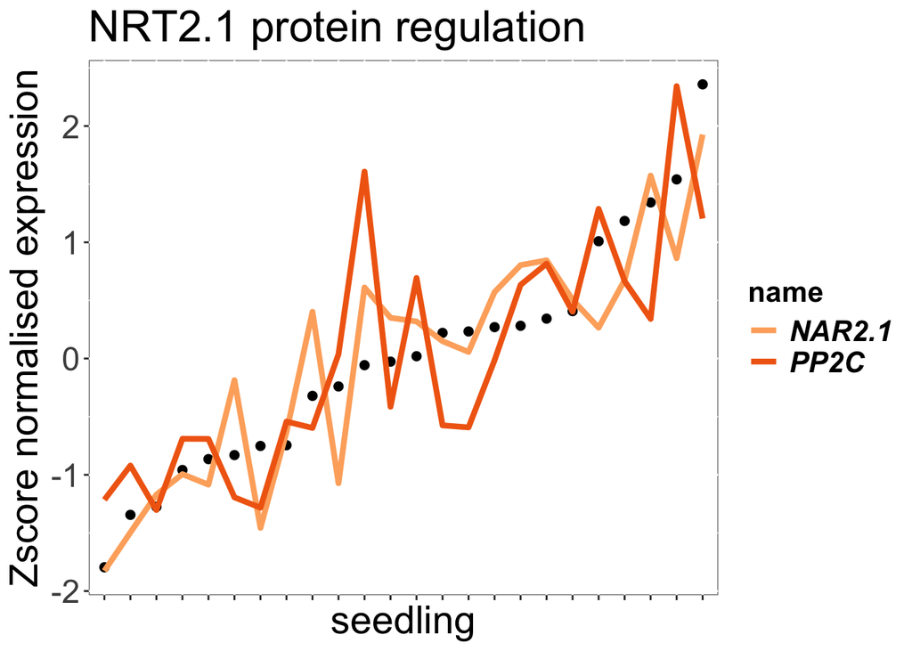

```r
# Graph for genes involved in NRT2.1 protein regulation


my_colors_lightgreens <- RColorBrewer::brewer.pal(9, "Oranges")[c(4,6)]


CPM_SC18_all_WT_Zscore_long_lessNRT2.1_NprotRegul <- filter(CPM_SC18_all_WT_Zscore_long_lessNRT2.1,
                                                                 type=="NRT2.1_protein_regulation")

ggplot(NRT2.1_CPM_SC18_all_WT_Zscore_long, aes(x=seedling, y=Zscore_normalised_expression)) +
  geom_point(size=2) +
  geom_line(data=CPM_SC18_all_WT_Zscore_long_lessNRT2.1_NprotRegul, aes(x=seedling, y=Zscore_normalised_expression, group=name, color=name), size=1.5) +
  scale_color_manual(values=my_colors_lightgreens, labels=c(expression(bolditalic("NAR2.1")),
                                                       expression(bolditalic("PP2C")))) +
  ylab("Zscore normalised expression") +
  ggtitle("NRT2.1 protein regulation") +
  theme(legend.text=element_text(size=16,face = "italic" ),legend.title = element_text(size=16, face="bold"),
        axis.text=element_text(size=18), axis.title=element_text(size=21.5),
        plot.title = element_text(size=24),
        panel.background = element_rect(fill = "white", colour = "grey50"),axis.text.x=element_blank(), legend.key = element_rect(fill = NA, color = NA))
```

```r
ggsave("Correlation_NRT2.1_NprotRegulation_seedlings.jpg", width=5, height=4)
```

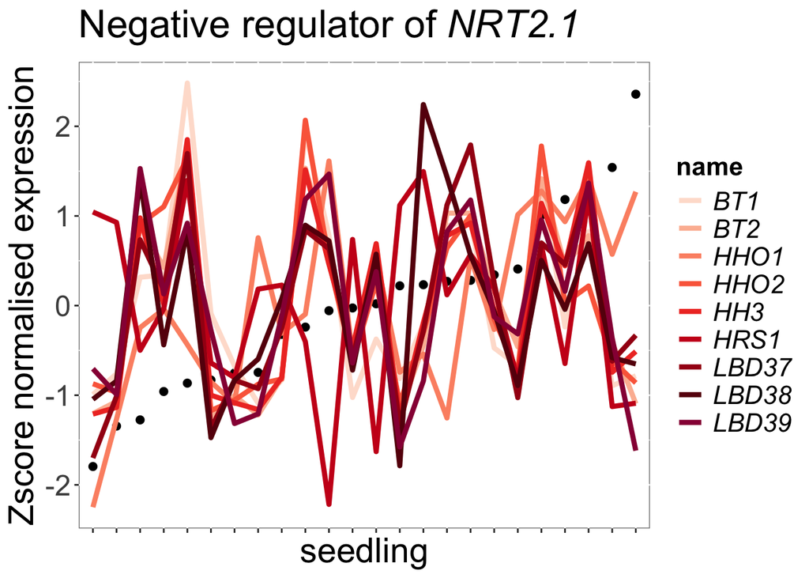

```r
# Graph for genes involved in negative regulation of NRT2.1 gene

my_colors_purples <- c(RColorBrewer::brewer.pal(9, "Reds")[2:9],RColorBrewer::brewer.pal(9, "PuRd")[8])



CPM_SC18_all_WT_Zscore_long_lessNRT2.1_NnegRegul <- filter(CPM_SC18_all_WT_Zscore_long_lessNRT2.1,
                                                                 type=="Negative_regulator_NRT2.1")

ggplot(NRT2.1_CPM_SC18_all_WT_Zscore_long, aes(x=seedling, y=Zscore_normalised_expression)) +
  geom_point(size=2) +
  geom_line(data=CPM_SC18_all_WT_Zscore_long_lessNRT2.1_NnegRegul, aes(x=seedling, y=Zscore_normalised_expression, group=name, color=name), size=1.5) +
   scale_color_manual(values=my_colors_purples, labels=c("BT1", "BT2", "HHO1", "HHO2", "HH3",
                                                             "HRS1", "LBD37", "LBD38", "LBD39")) +
  ylab("Zscore normalised expression") +
  ggtitle(expression(paste("Negative regulator of ", italic("NRT2.1")))) +
  theme(legend.text=element_text(size=16,face = "italic" ),legend.title = element_text(size=16, face="bold"),
        axis.text=element_text(size=18), axis.title=element_text(size=21.5),
        plot.title = element_text(size=24),
        panel.background = element_rect(fill = "white", colour = "grey50"),axis.text.x=element_blank(), legend.key = element_rect(fill = NA, color = NA))
```

```r
ggsave("Correlation_NRT2.1_NegativeRegulator_seedlings.jpg", width=5, height=4)
```

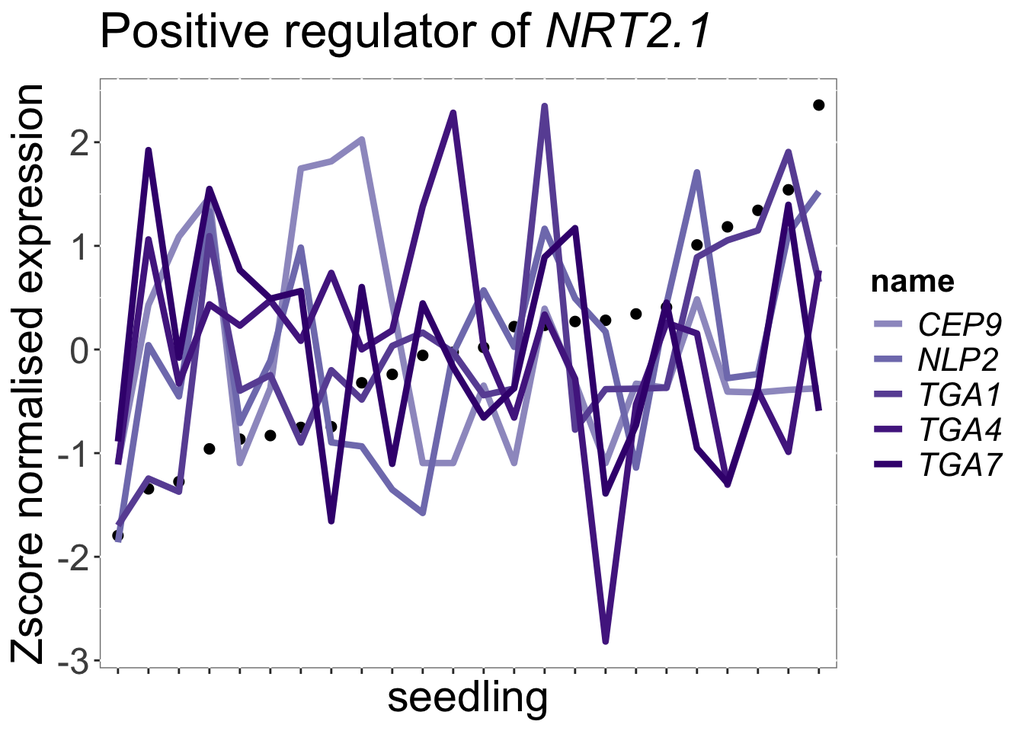

```r
# Graph for genes involved in positive regulation of NRT2.1 gene

my_colors_darkYellow <- RColorBrewer::brewer.pal(9, "Purples")[5:9]



CPM_SC18_all_WT_Zscore_long_lessNRT2.1_NposRegul <- filter(CPM_SC18_all_WT_Zscore_long_lessNRT2.1,
                                                                 type=="Positive_regulator_NRT2.1")

ggplot(NRT2.1_CPM_SC18_all_WT_Zscore_long, aes(x=seedling, y=Zscore_normalised_expression)) +
  geom_point(size=2) +
  geom_line(data=CPM_SC18_all_WT_Zscore_long_lessNRT2.1_NposRegul, aes(x=seedling, y=Zscore_normalised_expression, group=name, color=name), size=1.5) +
  scale_color_manual(values=my_colors_darkYellow, labels=c("CEP9", "NLP2", "TGA1", "TGA4", "TGA7")) +
  ylab("Zscore normalised expression") +
  ggtitle(expression(paste("Positive regulator of ", italic("NRT2.1")))) +
  theme(legend.text=element_text(size=16,face = "italic" ),legend.title = element_text(size=16, face="bold"),
        axis.text=element_text(size=18), axis.title=element_text(size=21.5),
        plot.title = element_text(size=24),
        panel.background = element_rect(fill = "white", colour = "grey50"),axis.text.x=element_blank(), legend.key = element_rect(fill = NA, color = NA))
```

```r
ggsave("Correlation_NRT2.1_PositiveRegulator_seedlings.jpg", width=5, height=4)
```

## Heatmap and hierarchical clustering of genes to see what is correlated with NRT2.1

### Heatmap on Zscore

```r
CPM_SC18_all_WTgenes_Zscore <- mutate_all(CPM_SC18_all_WT, funs("Zscore" = (.-rowMeans(CPM_SC18_all_WT[,1:24], na.rm=TRUE))/rowSds(as.matrix(CPM_SC18_all_WT[,1:24])))) %>%
  dplyr::select( contains("Zscore")) %>%
  rename_with(~ gsub("_Zscore", "", .x, fixed = TRUE)) %>%
  rownames_to_column(var="gene")
```

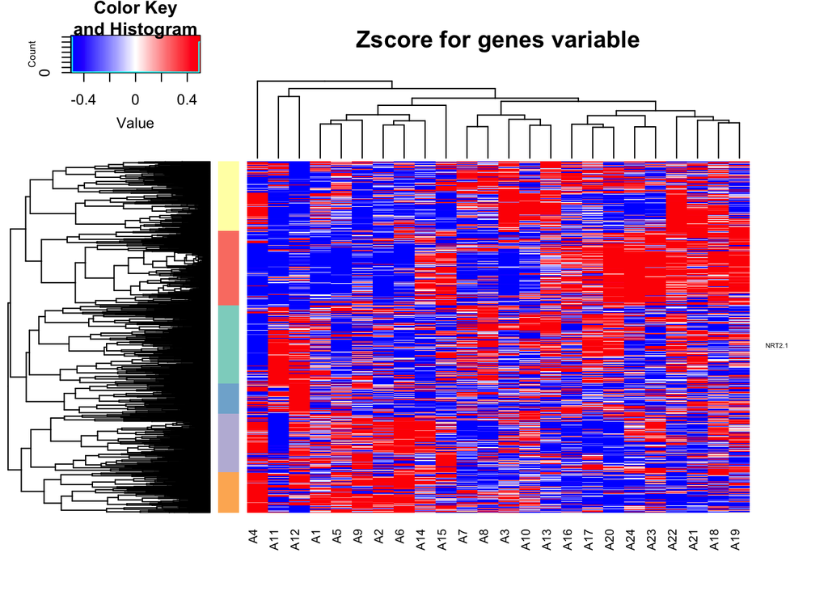

```r
CPM_SC18_all_WT_Zscore_BioVarsupp1 <- inner_join(CPM_SC18_all_WTgenes_Zscore, CPM_SC18_all_WT_expr_Brennecke_data,
                                                by=c("gene"="Gene")) %>%
  filter(BioVar>= 1) %>%
  mutate(NRT21=case_when(gene=="AT1G08090" ~ "NRT2.1"))




CPM_SC18_all_WT_Zscore_BioVarsupp1.pearson <- cor(t(CPM_SC18_all_WT_Zscore_BioVarsupp1[,2:25]), method = "pearson")
CPM_SC18_all_WT_Zscore_BioVarsupp1.pearson[is.na(CPM_SC18_all_WT_Zscore_BioVarsupp1.pearson)]<-0
CPM_SC18_all_WT_Zscore_BioVarsupp1.pearson.dist<-as.dist((1-CPM_SC18_all_WT_Zscore_BioVarsupp1.pearson))
CPM_SC18_all_WT_Zscore_BioVarsupp1.pearson.dist[is.na(CPM_SC18_all_WT_Zscore_BioVarsupp1.pearson.dist)]<-0
CPM_SC18_all_WT_Zscore_BioVarsupp1.pearson.dist.clust.complete <- hclust(CPM_SC18_all_WT_Zscore_BioVarsupp1.pearson.dist,
                                                       method="complete")
CPM_SC18_all_WT_Zscore_BioVarsupp1.pearson.dist.clust.complete.den <- as.dendrogram(CPM_SC18_all_WT_Zscore_BioVarsupp1.pearson.dist.clust.complete)
CPM_SC18_all_WT_Zscore_BioVarsupp1.pearson.dist.clust.complete.col=brewer.pal(12, 'Set3')[cutree(CPM_SC18_all_WT_Zscore_BioVarsupp1.pearson.dist.clust.complete, k = 6)]
CPM_SC18_all_WT_Zscore_BioVarsupp1$cluster_6_pearson <- cutree(CPM_SC18_all_WT_Zscore_BioVarsupp1.pearson.dist.clust.complete,
                                             k = 6)
CPM_SC18_all_WT_Zscore_BioVarsupp1$cluster_6_pearson_color <- brewer.pal(12, 'Set3')[cutree(CPM_SC18_all_WT_Zscore_BioVarsupp1.pearson.dist.clust.complete, k = 6)]


heatmap.2(as.matrix(CPM_SC18_all_WT_Zscore_BioVarsupp1[,2:25]),
          Rowv=CPM_SC18_all_WT_Zscore_BioVarsupp1.pearson.dist.clust.complete.den,
          col = bluered(100), breaks=seq(-0.5,0.5,length.out=101), trace = 'none' ,
          labRow=CPM_SC18_all_WT_Zscore_BioVarsupp1$NRT21, labCol=names(CPM_SC18_all_WT_Zscore_BioVarsupp1[,2:25]),
          main="Zscore for genes variable",
          RowSideColors = CPM_SC18_all_WT_Zscore_BioVarsupp1.pearson.dist.clust.complete.col,
          na.rm=F, na.color="black")
```

```r
pdf("heatmap_clusters_single_seedlings_CVsup1_NRT21.pdf")
heatmap.2(as.matrix(CPM_SC18_all_WT_Zscore_BioVarsupp1[,2:25]),
          Rowv=CPM_SC18_all_WT_Zscore_BioVarsupp1.pearson.dist.clust.complete.den,
          col = bluered(100), breaks=seq(-0.5,0.5,length.out=101), trace = 'none' ,
          labRow=CPM_SC18_all_WT_Zscore_BioVarsupp1$NRT21, labCol=names(CPM_SC18_all_WT_Zscore_BioVarsupp1[,2:25]),
          main="Zscore for genes variable",
          RowSideColors = CPM_SC18_all_WT_Zscore_BioVarsupp1.pearson.dist.clust.complete.col,
          na.rm=F, na.color="black")
dev.off()
```

```r
write_tsv(CPM_SC18_all_WT_Zscore_BioVarsupp1, file="6clusters_genesCVsup1_NRT21.txt")
```

# Profile of clusters compared with NRT2.1

```r
AllClusters <- read_tsv("6clusters_genesCVsup1_NRT21.txt")
```

plot profile of NRT2.1 and profile of cluster1 where NRT2.1 is

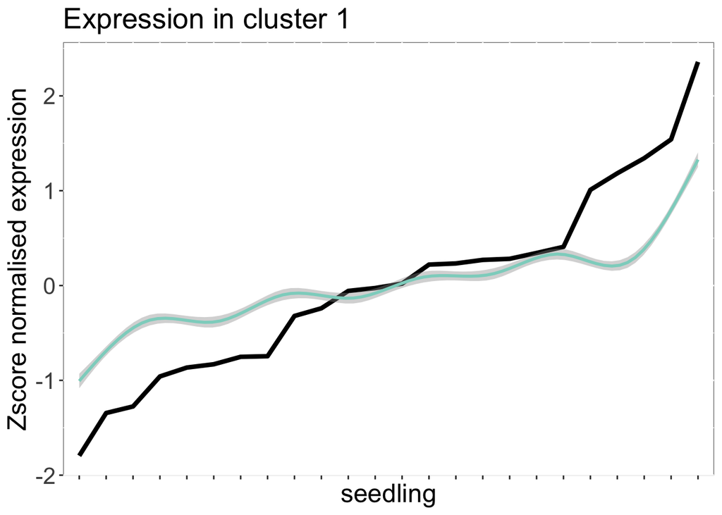

```r
Cluster1_long <- filter(AllClusters, cluster_6_pearson==1) %>%
  pivot_longer( cols = c(A1:A9), names_to = "seedling", values_to = "Zscore_normalised_expression")


NRT2.1_long <- filter(AllClusters, gene=="AT1G08090") %>%
  pivot_longer( cols = c(A1:A9), names_to = "seedling", values_to = "Zscore_normalised_expression")  %>%
  mutate(seedling=fct_reorder(seedling, Zscore_normalised_expression))


ggplot(NRT2.1_long, aes(x=seedling, y=Zscore_normalised_expression)) +
  geom_line(size=1.5, aes(group=gene)) +
  geom_smooth(data=Cluster1_long, aes(x=seedling, y=Zscore_normalised_expression, group=cluster_6_pearson, color=cluster_6_pearson_color)) +
  scale_color_manual(values="#8DD3C7") +
  ylab("Zscore normalised expression") +
  ggtitle("Expression in cluster 1") +
  theme(legend.text=element_text(size=16),legend.title = element_text(size=16, face="bold"),
        axis.text=element_text(size=16), axis.title=element_text(size=18),
        plot.title = element_text(size=20),
        panel.background = element_rect(fill = "white", colour = "grey50"),axis.text.x=element_blank(),
        legend.position = "none")
```

```r
ggsave("Expression_cluster1_NRT2.1.jpg", width=4.5, height = 4.5)
```

plot profile of NRT2.1 and profile of cluster2

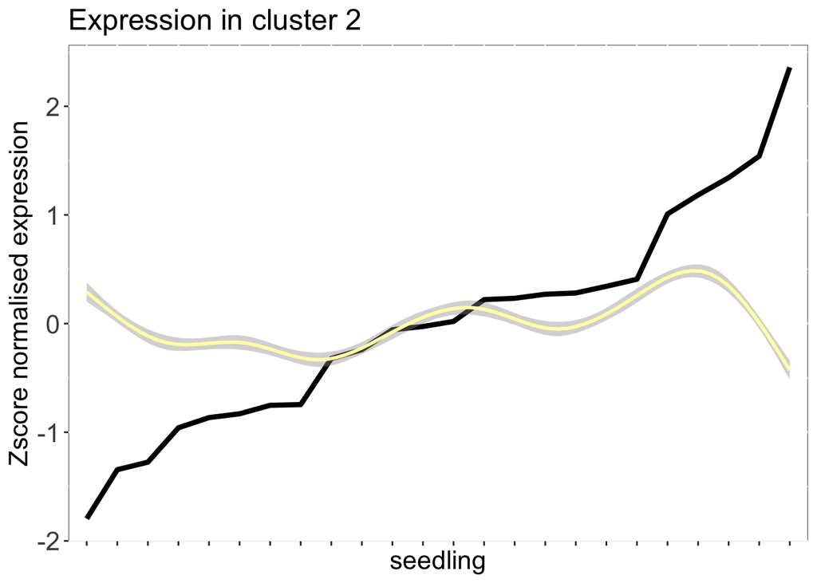

```r
Cluster2_long <- filter(AllClusters, cluster_6_pearson==2) %>%
  pivot_longer( cols = c(A1:A9), names_to = "seedling", values_to = "Zscore_normalised_expression")


NRT2.1_long <- filter(AllClusters, gene=="AT1G08090") %>%
  pivot_longer( cols = c(A1:A9), names_to = "seedling", values_to = "Zscore_normalised_expression")  %>%
  mutate(seedling=fct_reorder(seedling, Zscore_normalised_expression))


ggplot(NRT2.1_long, aes(x=seedling, y=Zscore_normalised_expression)) +
  geom_line(size=1.5, aes(group=gene)) +
  geom_smooth(data=Cluster2_long, aes(x=seedling, y=Zscore_normalised_expression, group=cluster_6_pearson, color=cluster_6_pearson_color)) +
  scale_color_manual(values="#FFFFB3") +
  ylab("Zscore normalised expression") +
  ggtitle("Expression in cluster 2") +
  theme(legend.text=element_text(size=16),legend.title = element_text(size=16, face="bold"),
        axis.text=element_text(size=16), axis.title=element_text(size=16),
        plot.title = element_text(size=18),
        panel.background = element_rect(fill = "white", colour = "grey50"),axis.text.x=element_blank(),
        legend.position = "none")
```

```r
ggsave("Expression_cluster2_NRT2.1.jpg", width=5, height = 5)
```

plot profile of NRT2.1 and profile of cluster3

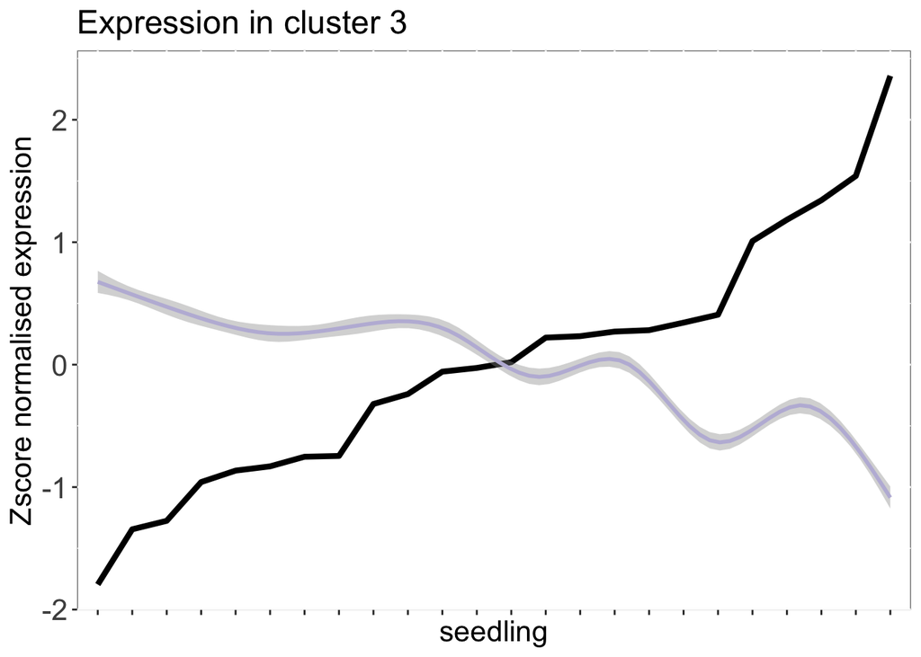

```r
Cluster3_long <- filter(AllClusters, cluster_6_pearson==3) %>%
  pivot_longer( cols = c(A1:A9), names_to = "seedling", values_to = "Zscore_normalised_expression")


NRT2.1_long <- filter(AllClusters, gene=="AT1G08090") %>%
  pivot_longer( cols = c(A1:A9), names_to = "seedling", values_to = "Zscore_normalised_expression")  %>%
  mutate(seedling=fct_reorder(seedling, Zscore_normalised_expression))


ggplot(NRT2.1_long, aes(x=seedling, y=Zscore_normalised_expression)) +
  geom_line(size=1.5, aes(group=gene)) +
  geom_smooth(data=Cluster3_long, aes(x=seedling, y=Zscore_normalised_expression, group=cluster_6_pearson, color=cluster_6_pearson_color)) +
  scale_color_manual(values="#BEBADA") +
  ylab("Zscore normalised expression") +
  ggtitle("Expression in cluster 3") +
  theme(legend.text=element_text(size=16),legend.title = element_text(size=16, face="bold"),
        axis.text=element_text(size=16), axis.title=element_text(size=16),
        plot.title = element_text(size=18),
        panel.background = element_rect(fill = "white", colour = "grey50"),axis.text.x=element_blank(),
        legend.position = "none")
```

```r
ggsave("Expression_cluster3_NRT2.1.jpg", width=5, height = 5)
```

plot profile of NRT2.1 and profile of cluster4

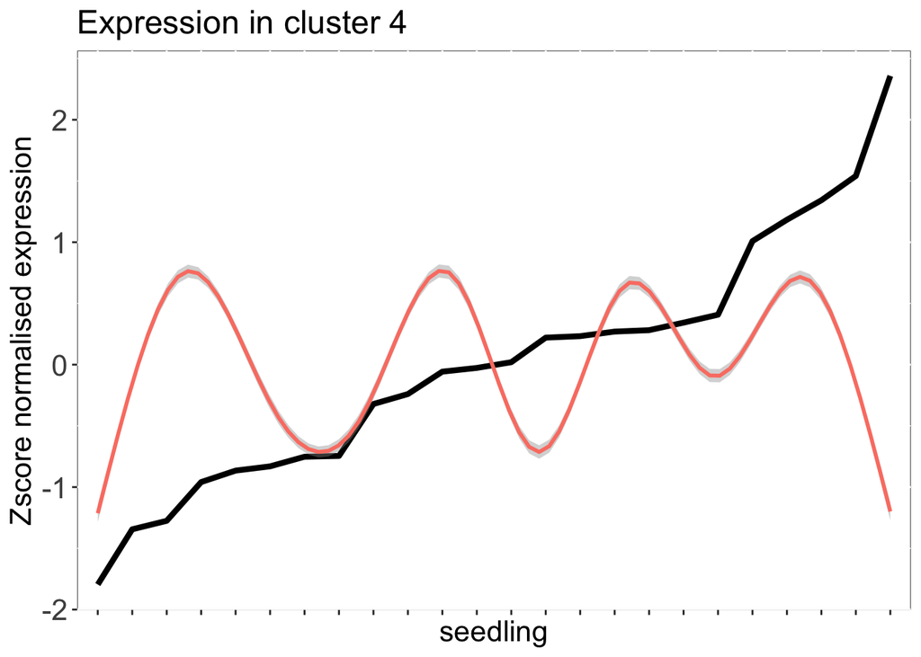

```r
Cluster4_long <- filter(AllClusters, cluster_6_pearson==4) %>%
  pivot_longer( cols = c(A1:A9), names_to = "seedling", values_to = "Zscore_normalised_expression")


NRT2.1_long <- filter(AllClusters, gene=="AT1G08090") %>%
  pivot_longer( cols = c(A1:A9), names_to = "seedling", values_to = "Zscore_normalised_expression")  %>%
  mutate(seedling=fct_reorder(seedling, Zscore_normalised_expression))


ggplot(NRT2.1_long, aes(x=seedling, y=Zscore_normalised_expression)) +
  geom_line(size=1.5, aes(group=gene)) +
  geom_smooth(data=Cluster4_long, aes(x=seedling, y=Zscore_normalised_expression, group=cluster_6_pearson, color=cluster_6_pearson_color)) +
  scale_color_manual(values="#FB8072") +
  ylab("Zscore normalised expression") +
  ggtitle("Expression in cluster 4") +
  theme(legend.text=element_text(size=16),legend.title = element_text(size=16, face="bold"),
        axis.text=element_text(size=16), axis.title=element_text(size=16),
        plot.title = element_text(size=18),
        panel.background = element_rect(fill = "white", colour = "grey50"),axis.text.x=element_blank(),
        legend.position = "none")
```

```r
ggsave("Expression_cluster4_NRT2.1.jpg", width=5, height = 5)
```

plot profile of NRT2.1 and profile of cluster5

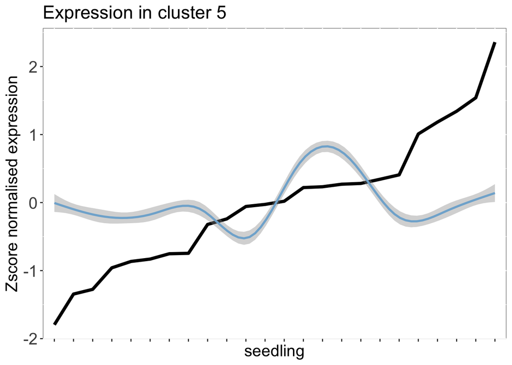

```r
Cluster5_long <- filter(AllClusters, cluster_6_pearson==5) %>%
  pivot_longer( cols = c(A1:A9), names_to = "seedling", values_to = "Zscore_normalised_expression")


NRT2.1_long <- filter(AllClusters, gene=="AT1G08090") %>%
  pivot_longer( cols = c(A1:A9), names_to = "seedling", values_to = "Zscore_normalised_expression")  %>%
  mutate(seedling=fct_reorder(seedling, Zscore_normalised_expression))


ggplot(NRT2.1_long, aes(x=seedling, y=Zscore_normalised_expression)) +
  geom_line(size=1.5, aes(group=gene)) +
  geom_smooth(data=Cluster5_long, aes(x=seedling, y=Zscore_normalised_expression, group=cluster_6_pearson, color=cluster_6_pearson_color)) +
  scale_color_manual(values="#80B1D3") +
  ylab("Zscore normalised expression") +
  ggtitle("Expression in cluster 5") +
  theme(legend.text=element_text(size=16),legend.title = element_text(size=16, face="bold"),
        axis.text=element_text(size=16), axis.title=element_text(size=16),
        plot.title = element_text(size=18),
        panel.background = element_rect(fill = "white", colour = "grey50"),axis.text.x=element_blank(),
        legend.position = "none")
```

```r
ggsave("Expression_cluster5_NRT2.1.jpg", width=5, height = 5)
```

plot profile of NRT2.1 and profile of cluster6

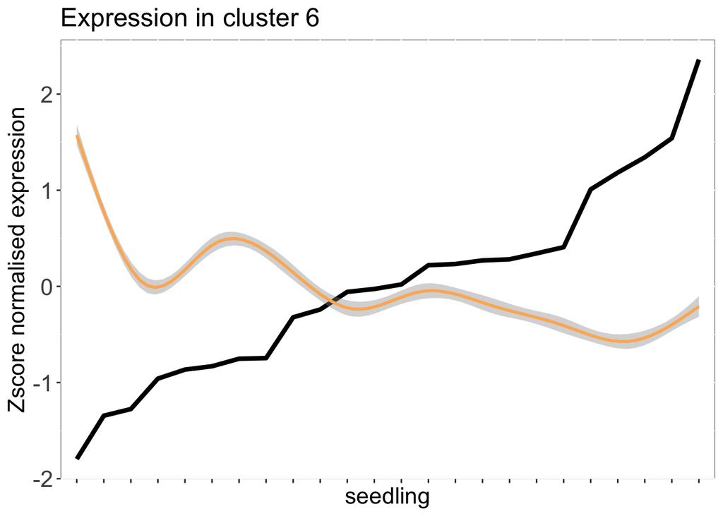

```r
Cluster6_long <- filter(AllClusters, cluster_6_pearson==6) %>%
  pivot_longer( cols = c(A1:A9), names_to = "seedling", values_to = "Zscore_normalised_expression")


NRT2.1_long <- filter(AllClusters, gene=="AT1G08090") %>%
  pivot_longer( cols = c(A1:A9), names_to = "seedling", values_to = "Zscore_normalised_expression")  %>%
  mutate(seedling=fct_reorder(seedling, Zscore_normalised_expression))


ggplot(NRT2.1_long, aes(x=seedling, y=Zscore_normalised_expression)) +
  geom_line(size=1.5, aes(group=gene)) +
  geom_smooth(data=Cluster6_long, aes(x=seedling, y=Zscore_normalised_expression, group=cluster_6_pearson, color=cluster_6_pearson_color)) +
  scale_color_manual(values="#FDB462") +
  ylab("Zscore normalised expression") +
  ggtitle("Expression in cluster 6") +
  theme(legend.text=element_text(size=16),legend.title = element_text(size=16, face="bold"),
        axis.text=element_text(size=16), axis.title=element_text(size=16),
        plot.title = element_text(size=18),
        panel.background = element_rect(fill = "white", colour = "grey50"),axis.text.x=element_blank(),
        legend.position = "none")
```

```r
ggsave("Expression_cluster6_NRT2.1.jpg", width=5, height = 5)
```

# Volcano plot showing the correlation of genes in each cluster with NRT2.1

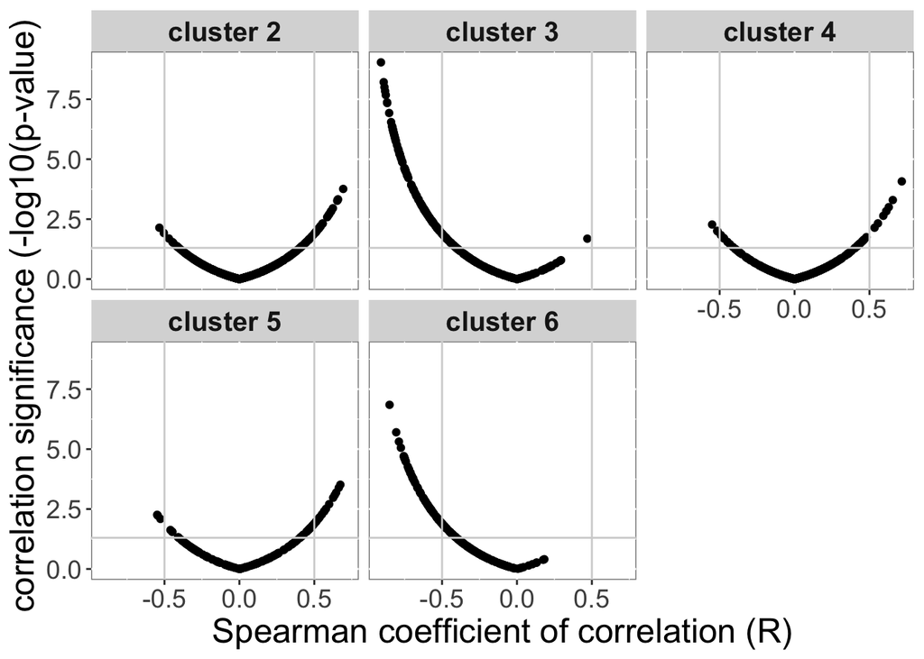

```r
cluster_info <- dplyr::select(AllClusters, gene, cluster_6_pearson)

CPM_SC18_all_WT_Zscore_1ColperGene <- pivot_longer(AllClusters, cols = c(A1:A9), names_to = "seedling", values_to = "Zscore_normalised_expression") %>%
  dplyr::select(gene, seedling, Zscore_normalised_expression) %>%
  pivot_wider(names_from = gene, values_from = Zscore_normalised_expression) %>%
  column_to_rownames(var="seedling")


Rcor_NRT2.1_genes_clusters <- sapply(CPM_SC18_all_WT_Zscore_1ColperGene, function(x) corr.test(x, CPM_SC18_all_WT_Zscore_1ColperGene$AT1G08090, method="spearman")$r) %>%
  as.data.frame() %>%
  rownames_to_column(var="gene") %>%
  dplyr::rename("Rcor" =".") %>%
  inner_join(cluster_info, by="gene")


Pcor_NRT2.1_genes_clusters <- sapply(CPM_SC18_all_WT_Zscore_1ColperGene, function(x) corr.test(x, CPM_SC18_all_WT_Zscore_1ColperGene$AT1G08090, method="spearman")$p) %>%
  as.data.frame()%>%
  rownames_to_column(var="gene") %>%
  dplyr::rename("Pcor" =".")

Corr_NRT2.1_genes_clusters <- inner_join(Rcor_NRT2.1_genes_clusters, Pcor_NRT2.1_genes_clusters, by="gene") %>%
  filter(gene!="AT1G08090")


filter(Corr_NRT2.1_genes_clusters, cluster_6_pearson!="1") %>%
mutate(cluster_6_pearson=paste("cluster", cluster_6_pearson)) %>%
  mutate(cluster_6_pearson=factor(cluster_6_pearson, levels=c("cluster 2", "cluster 3",
                                  "cluster 4", "cluster 5", "cluster 6")),
       logCorr=-log(Pcor, 10)) %>%
ggplot( aes(x=Rcor, y=logCorr)) +
  geom_point() +
  ylab("correlation significance (-log10(p-value)") +
  xlab("Spearman coefficient of correlation (R)") +
  geom_vline(xintercept = -0.5, col="lightgrey") +
  geom_vline(xintercept = 0.5, col="lightgrey") +
  geom_hline(yintercept = 1.30103, col="lightgrey") +
  facet_wrap(.~cluster_6_pearson, ncol = 3) +
  scale_color_brewer(palette="Set2", name="P-value",labels=c("less0.05"="Lower than 0.05", "more0.05"="Higher than 0.05"))+
   theme(legend.text=element_text(size=15),legend.title = element_text(size=15, face="bold"),
        axis.text=element_text(size=14), axis.title=element_text(size=18.5),
        plot.title = element_text(size=16),strip.text = element_text( face="bold", size=15),
        panel.background = element_rect(fill = "white", colour = "grey50"))
```

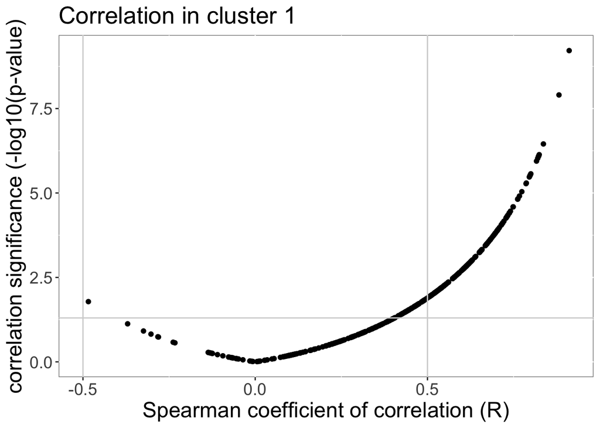

```r
ggsave(file="volcano_plot_cor_NRT2.1_clusters_except1.jpg", width=10, height=5)



filter(Corr_NRT2.1_genes_clusters, cluster_6_pearson=="1") %>%
mutate(cluster_6_pearson=paste("cluster", cluster_6_pearson), logCorr=-log(Pcor, 10)) %>%
ggplot( aes(x=Rcor, y=logCorr)) +
  geom_point() +
  ylab("correlation significance (-log10(p-value)") +
  xlab("Spearman coefficient of correlation (R)") +
  geom_vline(xintercept = -0.5, col="lightgrey") +
  geom_vline(xintercept = 0.5, col="lightgrey") +
  geom_hline(yintercept = 1.30103, col="lightgrey") +
  ggtitle("Correlation in cluster 1") +
  scale_color_brewer(palette="Set2", name="P-value",labels=c("less0.05"="Lower than 0.05", "more0.05"="Higher than 0.05"))+
   theme(legend.text=element_text(size=15),legend.title = element_text(size=15, face="bold"),
        axis.text=element_text(size=14), axis.title=element_text(size=18),
        plot.title = element_text(size=20),strip.text = element_text( face="bold", size=15),
        panel.background = element_rect(fill = "white", colour = "grey50"))
```

```r
ggsave(file="volcano_plot_cor_NRT2.1_cluster1.jpg", width=5, height=5)
```

## Comparison with targets of NLP7

Tables of correlation between each gene and NRT2.1 for NLP7 targets

```r
options(scipen=999)

targets_NLP7 <- read_tsv("NLP7_targets_Marchive_2013.txt")
CPM_SC18_all_WT_Zscore_1ColperGene_nlp7 <- inner_join(CPM_SC18_all_WT_Zscore, targets_NLP7, by=c("gene"="AGI")) %>%
  pivot_longer( cols = c(A1:A9), names_to = "seedling", values_to = "Zscore_normalised_expression") %>%
  dplyr::select(-type, -nitrate_response_nlp7_compared_wt) %>%
  pivot_wider(names_from = gene, values_from = Zscore_normalised_expression) %>%
  column_to_rownames(var="seedling")

Rcor_NRT2.1_genes_nlp7 <- sapply(CPM_SC18_all_WT_Zscore_1ColperGene_nlp7, function(x) corr.test(x, CPM_SC18_all_WT_Zscore_1ColperGene_nlp7$AT1G08090, method="spearman")$r) %>%
  as.data.frame() %>%
  rownames_to_column(var="gene") %>%
  dplyr::rename("Rcor" =".") %>%
  inner_join(targets_NLP7, by=c("gene"="AGI"))


Pcor_NRT2.1_genes_nlp7 <- sapply(CPM_SC18_all_WT_Zscore_1ColperGene_nlp7, function(x) corr.test(x, CPM_SC18_all_WT_Zscore_1ColperGene_nlp7$AT1G08090, method="spearman")$p) %>%
  as.data.frame()%>%
  rownames_to_column(var="gene") %>%
  dplyr::rename("Pcor" =".")

Corr_NRT2.1_genes_nlp7 <- inner_join(Rcor_NRT2.1_genes_nlp7, Pcor_NRT2.1_genes_nlp7, by="gene") %>%
  filter(gene!="AT1G08090")
```

```r
## Ribbon for NLP7 targets


targets_NLP7 <- read_tsv("NLP7_targets_Marchive_2013.txt")
```

```
## `geom_line()`: Each group consists of only one observation.
## ℹ Do you need to adjust the group aesthetic?
```

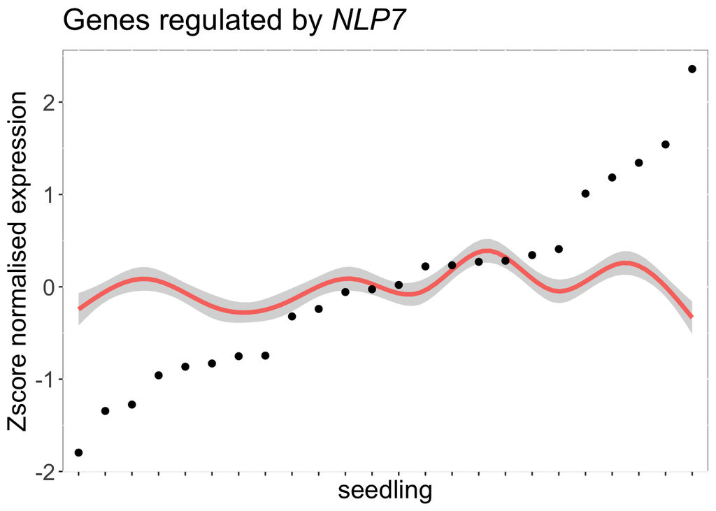

```r
CPM_SC18_all_WT_Zscore_long_nlp7 <- inner_join(CPM_SC18_all_WT_Zscore, targets_NLP7, by=c("gene"="AGI")) %>%
  pivot_longer( cols = c(A1:A9), names_to = "seedling", values_to = "Zscore_normalised_expression")


CPM_SC18_all_WT_Zscore_long_NRT21 <- filter(CPM_SC18_all_WT_Zscore_long_nlp7, gene=="AT1G08090") %>%
  mutate(seedling=fct_reorder(seedling, Zscore_normalised_expression))

CPM_SC18_all_WT_Zscore_long_lessNRT2.1_nlp7 <- filter(CPM_SC18_all_WT_Zscore_long_nlp7, gene!="AT1G08090")


ggplot(CPM_SC18_all_WT_Zscore_long_NRT21, aes(x=seedling, y=Zscore_normalised_expression)) +
  geom_line(size=2) +
  geom_smooth(data=CPM_SC18_all_WT_Zscore_long_lessNRT2.1_nlp7, aes(x=seedling, y=Zscore_normalised_expression, group=type, color=type), size=1.5) +
  geom_point(size=2) +
  ylab("Zscore normalised expression") +
  ggtitle(expression(paste("Genes regulated by ", italic("NLP7")))) +
  theme(legend.text=element_text(size=16),legend.title = element_text(size=16, face="bold"),
        axis.text=element_text(size=16), axis.title=element_text(size=18),
        plot.title = element_text(size=21),
        panel.background = element_rect(fill = "white", colour = "grey50"),axis.text.x=element_blank(),
        legend.position = "none")
```

```r
ggsave("Expression_nlp7Targets_smooth_NRT2.1.jpg", width=4, height = 4)
```

```
## `geom_line()`: Each group consists of only one observation.
## ℹ Do you need to adjust the group aesthetic?
```